Install Packages

```
library(tidyverse)




source('scripts/adams_theme.R') #for ggplot2
```

Import data

```
df <- read_csv('data/FireDataKlamath1987part1_v2.csv', col_types = cols(clusterID = col_factor())) %>%
  rbind(read_csv('data/FireDataKlamath1987part2_v2.csv', col_types = cols(clusterID = col_factor()))) %>%
  rbind(read_csv('data/FireDataKlamath1987part3_v2.csv', col_types = cols(clusterID = col_factor())))

eco_type_codes <- read_csv('data/landfire_ecotype_codes.csv')


n_pixels <- nrow(df)
```

clean data

```
df <- df %>%
  select(-.geo, -'system:index') %>%
  #filter(FIRE_YEAR == 1994) %>%
  mutate(pixelID = as.character(1:n_pixels))
```

Identifying patches with more than eight pixels

```
clusters_with_more_than8_pixels <- df %>% group_by(clusterID) %>%
  summarise(Npixels = length(unique(pixelID))) %>%
  filter(Npixels > 8) %>%
  pull(clusterID)
```

Creating a landcover data frame

```
landcover <- names(df)[grep(names(df), pattern = "NLCD")]

df_lc <- df %>%
  select(pixelID, clusterID, landcover) %>%
  gather(landcover, key = "NLCD_year", value = "landcover_code") %>%
  mutate(land_cover_name = case_when(
    (landcover_code == 71) ~ "grass_herb",
    (landcover_code == 51) ~ "shrub",
    (landcover_code == 42) ~ "evergreen_forest",
    (landcover_code == 43) ~ "mixed forest",
    (landcover_code == 31) ~ "barren_land",
    (landcover_code == 23) ~ "developed",
    (landcover_code == 41) ~ "deciduous_forest",
    (landcover_code == 11) ~ "open_water",
    (landcover_code == 81) ~ "pasture_hay",
    (landcover_code == 33) ~ "transitional_barren",
    (landcover_code == 52) ~ "shrub",
    (landcover_code == 21) ~ "developed",
    (landcover_code == 95) ~ "emergent_herb_wetlands",
    (landcover_code == 90) ~ "woody_wetlands",
    (landcover_code == 22) ~ "developed"
  )) %>%
  mutate(year = as.numeric(gsub("NLCD", "", NLCD_year))) %>%
  arrange(clusterID)

## Note: Using an external vector in selections is ambiguous.
## ℹ Use `all_of(landcover)` instead of `landcover` to silence this message.
## ℹ See <https://tidyselect.r-lib.org/reference/faq-external-vector.html>.

df_lc

## # A tibble: 262,520 x 6
##    pixelID clusterID NLCD_year landcover_code land_cover_name   year
##    <chr>   <fct>     <chr>              <dbl> <chr>            <dbl>
##  1 1       0         NLCD1992              42 evergreen_forest  1992
##  2 2       0         NLCD1992              71 grass_herb        1992
##  3 3       0         NLCD1992              42 evergreen_forest  1992
##  4 4       0         NLCD1992              42 evergreen_forest  1992
##  5 5       0         NLCD1992              42 evergreen_forest  1992
##  6 6       0         NLCD1992              71 grass_herb        1992
##  7 7       0         NLCD1992              71 grass_herb        1992
##  8 8       0         NLCD1992              71 grass_herb        1992
##  9 9       0         NLCD1992              42 evergreen_forest  1992
## 10 10      0         NLCD1992              42 evergreen_forest  1992
## # … with 262,510 more rows
```

Creating a tree canopy cover df

```
TCC <- names(df)[grep(names(df), pattern = "TCC")]

df_tcc <- df %>%
  select(pixelID, clusterID, TCC) %>%
  gather(TCC, key = "TCCyear", value = "pct_TCC") %>%
  mutate(year = as.numeric(gsub("TCC", "", TCCyear)))

## Note: Using an external vector in selections is ambiguous.
## ℹ Use `all_of(TCC)` instead of `TCC` to silence this message.
## ℹ See <https://tidyselect.r-lib.org/reference/faq-external-vector.html>.

df_tcc

## # A tibble: 98,445 x 5
##    pixelID clusterID TCCyear pct_TCC  year
##    <chr>   <fct>     <chr>     <dbl> <dbl>
##  1 1       0         TCC2000      30  2000
##  2 2       0         TCC2000       1  2000
##  3 3       0         TCC2000      49  2000
##  4 4       0         TCC2000      61  2000
##  5 5       0         TCC2000      66  2000
##  6 6       0         TCC2000       0  2000
##  7 7       0         TCC2000       0  2000
##  8 8       0         TCC2000      57  2000
##  9 9       0         TCC2000      69  2000
## 10 10      0         TCC2000      54  2000
## # … with 98,435 more rows
```

Creating an NBR dataframe

```
years <- as.character(1985:2017)
df_nbr <- df %>%
  select(pixelID, clusterID, years) %>%
  gather(years, key = "year_string", value = "NBR") %>%
  mutate(year = as.numeric(year_string)) %>%
  select(-year_string, -clusterID)

## Note: Using an external vector in selections is ambiguous.
## ℹ Use `all_of(years)` instead of `years` to silence this message.
## ℹ See <https://tidyselect.r-lib.org/reference/faq-external-vector.html>.

df_nbr

## # A tibble: 1,082,895 x 3
##    pixelID   NBR  year
##    <chr>   <dbl> <dbl>
##  1 1        745.  1985
##  2 2        617.  1985
##  3 3        414.  1985
##  4 4        682.  1985
##  5 5        729.  1985
##  6 6        764.  1985
##  7 7        489.  1985
##  8 8        603.  1985
##  9 9        736.  1985
## 10 10       632.  1985
## # … with 1,082,885 more rows
```

Creating a FACTS df

```
facts_cols <- names(df)[grep(names(df), pattern = "facts")]
df_facts <- df %>%
  select(pixelID, clusterID, facts_cols) %>%
  gather(facts_cols, key = "facts_year", value = "factsTreatmentCode") %>%
  mutate(factsTreatment = case_when(
    (factsTreatmentCode == 0) ~ "none",
    (factsTreatmentCode == 4431) ~ "plant_trees",
    (factsTreatmentCode == 4432) ~ "replant_or_fill"
  )) %>%
  mutate(year = as.numeric(gsub("facts", "", facts_year))) %>%
  arrange(clusterID)

## Note: Using an external vector in selections is ambiguous.
## ℹ Use `all_of(facts_cols)` instead of `facts_cols` to silence this message.
## ℹ See <https://tidyselect.r-lib.org/reference/faq-external-vector.html>.

df_facts

## # A tibble: 1,050,080 x 6
##    pixelID clusterID facts_year factsTreatmentCode factsTreatment  year
##    <chr>   <fct>     <chr>                   <dbl> <chr>          <dbl>
##  1 1       0         facts1987                   0 none            1987
##  2 2       0         facts1987                   0 none            1987
##  3 3       0         facts1987                   0 none            1987
##  4 4       0         facts1987                   0 none            1987
##  5 5       0         facts1987                   0 none            1987
##  6 6       0         facts1987                   0 none            1987
##  7 7       0         facts1987                   0 none            1987
##  8 8       0         facts1987                   0 none            1987
##  9 9       0         facts1987                   0 none            1987
## 10 10      0         facts1987                   0 none            1987
## # … with 1,050,070 more rows
```

Merging dfs together

```
#mering dfs together
df <- df %>% select(pixelID, clusterID, FIRE_YEAR, FireID, burnSev, distance, northness, eastness, elevation, slope, b1, WID) %>%
  rename(ecotype_code = b1) %>%
  left_join(df_nbr, by = c("pixelID")) %>%
  left_join(df_lc,c("pixelID","year")) %>%
  left_join(df_facts,c("pixelID","year")) %>%
  mutate(burnSevLong = case_when(
    (burnSev == 0) ~ "background/no_data",
    (burnSev == 1) ~ "verylow/no_burn",
    (burnSev == 2) ~ "low",
    (burnSev == 3) ~ "med",
    (burnSev == 4) ~ "high"
  )) %>%
  mutate(eco_type = case_when(
    (ecotype_code == 549) ~ "MC_LM_Serp",
    (ecotype_code == 550) ~ "MC_UM_Serp",
    (ecotype_code == 551) ~ "MC_DrytoMes",
    (ecotype_code == 552) ~ "MC_Mes",
    (ecotype_code == 553) ~ "MixedOak",
    (ecotype_code == 554) ~ "MC_BO_LM",
    (ecotype_code == 555) ~ "Jeffrey_Ponderosa",
    (ecotype_code == 556) ~ "RedFir",
    (ecotype_code == 557) ~ "SubalpineWoodland",
    (ecotype_code == 558) ~ "Maritime_DFir_WHem"
  )) %>%
  filter(ecotype_code %in% eco_type_codes$eco_type_code)

df

## # A tibble: 1,003,068 x 24
##    pixelID clusterID.x FIRE_YEAR FireID burnSev distance northness eastness
##    <chr>   <fct>           <dbl> <chr>    <dbl>    <dbl>     <dbl>    <dbl>
##  1 1       0                1987 00000…       0        0    -0.563    0.827
##  2 1       0                1987 00000…       0        0    -0.563    0.827
##  3 1       0                1987 00000…       0        0    -0.563    0.827
##  4 1       0                1987 00000…       0        0    -0.563    0.827
##  5 1       0                1987 00000…       0        0    -0.563    0.827
##  6 1       0                1987 00000…       0        0    -0.563    0.827
##  7 1       0                1987 00000…       0        0    -0.563    0.827
##  8 1       0                1987 00000…       0        0    -0.563    0.827
##  9 1       0                1987 00000…       0        0    -0.563    0.827
## 10 1       0                1987 00000…       0        0    -0.563    0.827
## # … with 1,003,058 more rows, and 16 more variables: elevation <dbl>,
## #   slope <dbl>, ecotype_code <dbl>, WID <dbl>, NBR <dbl>, year <dbl>,
## #   clusterID.y <fct>, NLCD_year <chr>, landcover_code <dbl>,
## #   land_cover_name <chr>, clusterID <fct>, facts_year <chr>,
## #   factsTreatmentCode <dbl>, factsTreatment <chr>, burnSevLong <chr>,
## #   eco_type <chr>

#adding the ecotype descriptions
```

Checking representation of forest types. Make this a table.

```
#representation of forest types
df %>%
  group_by(eco_type) %>%
  summarise(number_pixels = length(unique(pixelID))) %>%
  drop_na() %>%
  mutate(sample_area_hectares = number_pixels * 900 / 10000) %>%
  ggplot(aes(eco_type, number_pixels)) +
  geom_bar(stat = "identity") +
  adams_theme +
  theme(axis.text.x = element_text(angle = 45, hjust = 1)) +
  ylab(label = "N pixels")
```

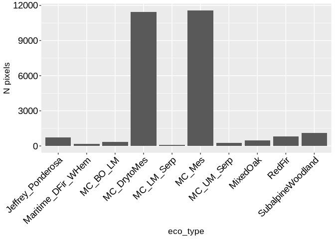

```
total_sample_area <- length(unique(df$pixelID)) * 900 / 10e4
total_sample_area

## [1] 273.564

total_number_patches <- length(unique(df$clusterID))
total_number_patches

## [1] 600
```

Exploring patch size in hectares and pixels

```
df %>%
  group_by(clusterID) %>%
  summarise(num_pixels_per_cluster = length(unique(pixelID))) %>%
  mutate(cluster_area = num_pixels_per_cluster * 900 / 10000) %>%
  pull(cluster_area) %>% summary()

## Warning: Factor `clusterID` contains implicit NA, consider using
## `forcats::fct_explicit_na`

##     Min.  1st Qu.   Median     Mean  3rd Qu.     Max.
##    0.090    0.720    2.340    9.119    5.850 2735.640

df %>%
  group_by(clusterID) %>%
  summarise(num_pixels_per_cluster = length(unique(pixelID))) %>%
  mutate(cluster_area = num_pixels_per_cluster * 900 / 10000) %>%
  ggplot(aes(num_pixels_per_cluster)) +
  geom_histogram() +
  xlim(c(0,100)) +
  adams_theme

## Warning: Factor `clusterID` contains implicit NA, consider using
## `forcats::fct_explicit_na`


## Warning: Removed 80 rows containing non-finite values (stat_bin).

## Warning: Removed 2 rows containing missing values (geom_bar).
```

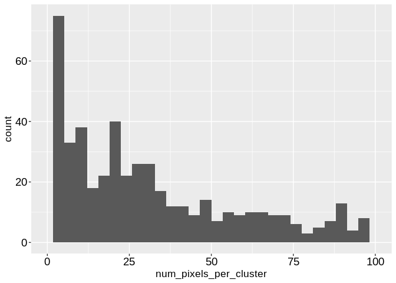

```
length(unique(df$pixelID))

## [1] 30396

length(unique(df$pixelID)) * 900 / 10e4

## [1] 273.564
```

Quantifying how many pixels went from non-forest back to forest in their post-fire regeneration trajectory

```
`%notin%` <- Negate(`%in%`)

nonForest2001 <- df %>%
  filter(year == 2001, landcover_code %notin% 41:43) %>%
  pull(pixelID) %>% unique()

#how many pixels went from shrub to tree
df %>%
  filter(pixelID %in% nonForest2001) %>%
  filter(year == 2016, landcover_code %in% 41:43) %>%
  pull(pixelID) %>% unique() %>% length()

## [1] 4576
```

Adding the percent NBR recovey to the df. %NBR recovery is the fraction of mean pre-fire NBR

```
#creating pre-fire NBR values for each pixel
pre_fire_nbr <- df %>%
  filter(year %in% 1985:1986) %>%
  group_by(pixelID) %>%
  summarise(preFireNBR = mean(NBR))

#adding the percent NBR recovery to the df
df <- df %>%
  left_join(pre_fire_nbr) %>%
  mutate(pct_nbr_recovery = NBR / preFireNBR)
```

Showing the distribution of NBR values for pixels classified as forest for NLCD

```
df %>%
  drop_na(land_cover_name) %>%
  filter(landcover_code %in% c(41:42, 71,51,52)) %>%
  ggplot(aes(x=NBR, fill=land_cover_name)) +
  geom_density( color="#e9ecef", alpha=0.6, position = 'identity') +
  scale_fill_manual(values=c("light green", "dark green", "yellow", "brown")) +
  #theme_ipsum() +
  labs(fill="") +
  adams_theme
```

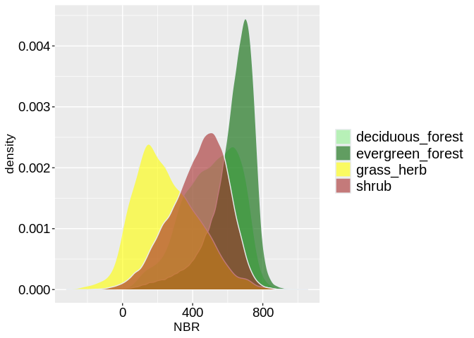

```
#patches <- sample(unique(df$clusterID),100)

df %>%
  group_by(FireID, clusterID, year) %>%
  summarise_if(is.numeric,mean) %>%
  #filter(clusterID %in% patches) %>%
  ggplot(aes(year,NBR,color = clusterID)) +
  geom_line() +
  adams_theme +
  theme(legend.position = "none")

## Warning: Factor `clusterID` contains implicit NA, consider using
## `forcats::fct_explicit_na`
```

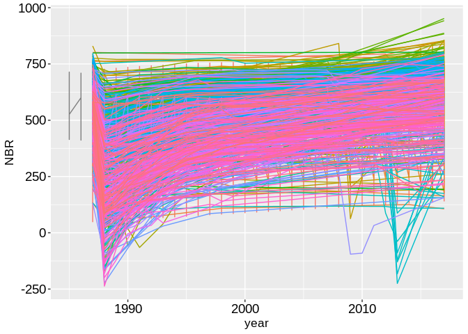

Calculating the percent NBR recovery for each patch

```
#patches <- sample(unique(df$clusterID),10)
df %>%
  group_by(clusterID, year) %>%
  #filter(WID > 0) %>%
  summarise_if(is.numeric,mean) %>%
  #filter(clusterID %in% patches) %>%
  ggplot(aes(year,pct_nbr_recovery,color = clusterID)) +
  geom_line() +
  ylim(c(-1,1.5)) +
  adams_theme +
  theme(legend.position = "none")

## Warning: Factor `clusterID` contains implicit NA, consider using
## `forcats::fct_explicit_na`

## Warning: Removed 625 row(s) containing missing values (geom_path).
```

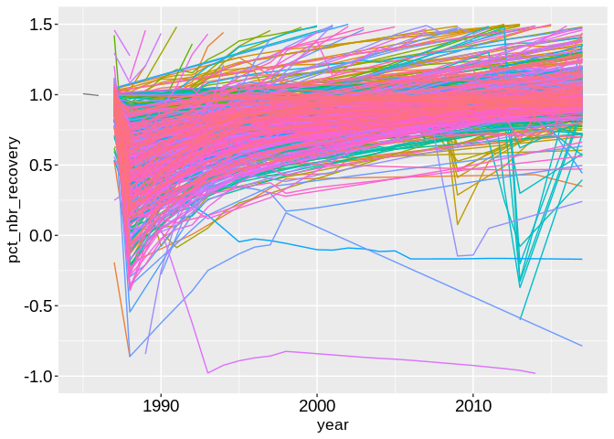

```
df %>%
  group_by(pixelID, year) %>%
  summarise_if(is.numeric,mean) %>%
  filter(year == 1992) %>%
  ggplot(aes(x = pct_nbr_recovery, fill = factor(burnSev))) +
  geom_density(alpha=0.6, position = 'identity') +
  scale_fill_brewer(palette = "Reds") +
  xlim(c(-0.2,2)) +
  xlab(label = "% NBR Recovery 5 years post-fire") +
  adams_theme +
  labs(fill="Burn Severity")

## Warning: Removed 397 rows containing non-finite values (stat_density).
```

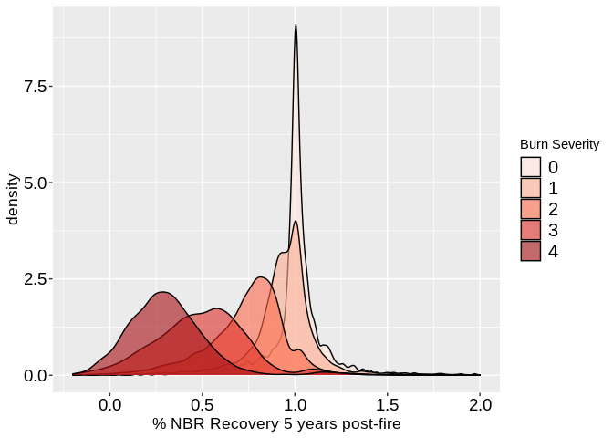

```
df %>%
  group_by(pixelID, year) %>%
  summarise_if(is.numeric,mean) %>%
  filter(year == 2017) %>%
  ggplot(aes(x = pct_nbr_recovery, fill = factor(burnSev))) +
  geom_density(alpha=0.6, position = 'identity') +
  scale_fill_brewer(palette = "Reds") +
  xlim(c(-0.2,2)) +
  xlab(label = "% NBR Recovery 30 years post-fire") +
  adams_theme +
  labs(fill="Burn Severity")

## Warning: Removed 1108 rows containing non-finite values (stat_density).
```

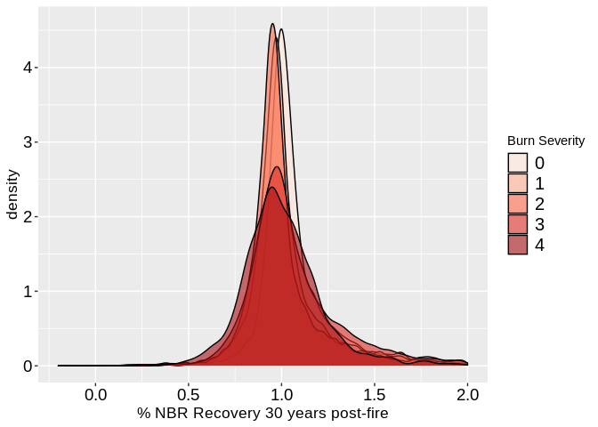

Creating variables showing the percent NBR recovery in 92,97,2017

```
df <- df %>%
  filter(pct_nbr_recovery >= -10)

pctNBRrec2017 <- df %>%
  filter(year == 2017) %>%
  select(pixelID, pct_nbr_recovery) %>%
  rename(pct_nbr_recovery_2017 = pct_nbr_recovery)

pctNBRrec1997 <- df %>%
  filter(year == 1997) %>%
  select(pixelID, pct_nbr_recovery) %>%
  rename(pct_nbr_recovery_1997 = pct_nbr_recovery)

pctNBRrec1992 <- df %>%
  filter(year == 1992) %>%
  select(pixelID, pct_nbr_recovery) %>%
  rename(pct_nbr_recovery_1992 = pct_nbr_recovery)

df <- df %>%
  left_join(pctNBRrec2017) %>%
  left_join(pctNBRrec1997) %>%
  left_join(pctNBRrec1992)
```

```
# df %>%
#   ggplot(aes(factor(burnSev), pct_nbr_recovery_1997)) +
#   geom_boxplot() +
#   ylim(c(0.2,1.5))
```

```
# df %>%
#   ggplot(aes(factor(burnSev), pct_nbr_recovery_2017)) +
#   geom_boxplot() +
#   ylim(c(0.2,1.5))
```

```
# pre_fire_pixels_forest <- df %>% filter(year == 1992, landcover_code %in% 41:42) %>% pull(pixelID)
#
# df %>%
#   filter(pixelID %in% pre_fire_pixels_forest) %>%
#   filter(burnSev >= 3) %>%
#   ggplot(aes(distance, pct_nbr_recovery_2017)) +
#   geom_point() +
#   scale_x_continuous() +
#   scale_y_continuous() +
#   xlim(c(0,500)) +
#   adams_theme
```

plot % tree cover over time for a random sample of clusters

```
#create data frame of the change in forest cover for each cluster
length(clusters_with_more_than8_pixels)

## [1] 455

patches <- sample(clusters_with_more_than8_pixels,100)

df %>%
  filter(burnSev > 1) %>%
  filter(clusterID %in% clusters_with_more_than8_pixels) %>%
  drop_na(land_cover_name) %>%
  group_by(clusterID,year) %>%
  summarise(pct_tree = sum(landcover_code %in% 41:43) / length(landcover_code)) %>%
  filter(clusterID %in% patches) %>%
  ggplot(aes(year,pct_tree,color = clusterID)) +
  geom_point() +
  geom_line() +
  adams_theme +
  theme(legend.position = "none") +
  scale_x_continuous(n.breaks = 7, limits = c(1992,2016)) +
  ylab(label = "Proportional Area Trees")
```

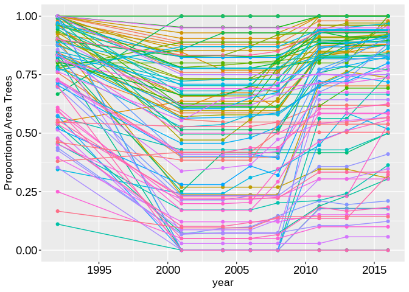

Whats the distribution in how much % tree canopy cover changed throughout the regeneration trajectory?

```
df %>%
  #filter(burnSev > 1) %>%
  filter(clusterID %in% clusters_with_more_than8_pixels) %>%
  #filter(WID > 0) %>%
  drop_na(land_cover_name) %>%
  group_by(clusterID,year) %>%
  summarise(pct_tree = sum(landcover_code %in% 41:43) / length(landcover_code),
            n_pixels = length(unique(pixelID))) %>%
  group_by(clusterID) %>%
  summarise(pct_change_tree = pct_tree[year==2016] - pct_tree[year==1992],
            n_pixels = head(n_pixels,1)) %>%
  ggplot(aes(pct_change_tree)) +
  geom_histogram() +
  adams_theme +
  xlab(label = "% change tree cover (2017-1992)")
```

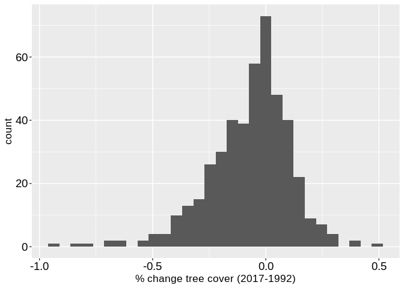

```
#A_mean = mean(values[value_type=="A"])
```

Calculate the patch-level independent variable (% change in forest cover)

```
patch_level_percent_change_in_forest_cover <- df %>%
  #filter(burnSev > 1) %>%
  filter(clusterID %in% clusters_with_more_than8_pixels) %>%
  drop_na(land_cover_name) %>%
  group_by(clusterID,year) %>%
  summarise(pct_tree = sum(landcover_code %in% 41:43) / length(landcover_code),
            n_pixels = length(unique(pixelID))) %>%
  group_by(clusterID) %>%
  summarise(pct_change_tree = pct_tree[year==2016] - pct_tree[year==1992],
            n_pixels = head(n_pixels,1))

names(patch_level_percent_change_in_forest_cover)

## [1] "clusterID"       "pct_change_tree" "n_pixels"
```

Calculate patch-level continuous predictor vars

```
patch_level_continuous_vars <- df %>%
  select(clusterID, pixelID, burnSev,northness,eastness,elevation,slope,preFireNBR, distance) %>%
  #mutate_at(vars(ecotype_code, factsTreatmentCode, WID),as.factor) %>%
  #filter(burnSev > 1) %>%
  filter(clusterID %in% clusters_with_more_than8_pixels) %>%
  group_by(clusterID) %>%
  summarise_if(is.numeric,mean)
names(patch_level_continuous_vars)

## [1] "clusterID"  "burnSev"    "northness"  "eastness"   "elevation"
## [6] "slope"      "preFireNBR" "distance"
```

Calculate patch-level categorical predictor vars

```
getmode <- function(x) {
   uniqv <- unique(x)
   uniqv[which.max(tabulate(match(x, uniqv)))]
}

patch_level_categorical_vars <- df %>%
  select(clusterID,pixelID,ecotype_code, eco_type, factsTreatmentCode, WID) %>%
  mutate_at(vars(ecotype_code, eco_type, factsTreatmentCode, WID),as.factor) %>%
  #filter(burnSev > 1) %>%
  filter(clusterID %in% clusters_with_more_than8_pixels) %>%
  group_by(clusterID) %>%
  summarise_if(is.factor,getmode)

names(patch_level_categorical_vars)

## [1] "clusterID"          "ecotype_code"       "eco_type"
## [4] "factsTreatmentCode" "WID"
```

Joining patch-level dataframes

```
patch_data  <- patch_level_percent_change_in_forest_cover %>%
  left_join(patch_level_continuous_vars, by = "clusterID") %>%
  left_join(patch_level_categorical_vars, by = "clusterID") %>%
  select(-clusterID, -n_pixels)

patch_data

## # A tibble: 454 x 12
##    pct_change_tree burnSev northness eastness elevation slope preFireNBR
##              <dbl>   <dbl>     <dbl>    <dbl>     <dbl> <dbl>      <dbl>
##  1         -0.0221 0.00500    0.0288   0.0259     1079.  19.2       598.
##  2         -0.0833 1.08      -0.774    0.627      1629.  28.0       653.
##  3         -0.375  3.31       0.643    0.731      1177.  26.8       536.
##  4         -0.105  3.32       0.395    0.850      1153.  26.4       481.
##  5         -0.20   3.1        0.365    0.914      1023   27.9       479.
##  6         -0.05   3.55       0.0851   0.866      1088.  26.2       494.
##  7         -0.198  1.95      -0.719    0.322       691.  24.5       624.
##  8         -0.0820 1.90      -0.664   -0.251       676.  23.1       715.
##  9         -0.337  2.13      -0.884   -0.271       791.  27.5       636.
## 10          0      2         -0.913   -0.211       516.  20.9       731.
## # … with 444 more rows, and 5 more variables: distance <dbl>,
## #   ecotype_code <fct>, eco_type <fct>, factsTreatmentCode <fct>, WID <fct>
```

Exploring correlations between variables

```
library(ggcorrplot)

corr <- patch_data %>%
  select_if(is.numeric) %>%
  cor() %>% round(1)

Pmat <- patch_data %>%
  select_if(is.numeric) %>%
  cor_pmat()

ggcorrplot(corr, hc.order = TRUE, type = "lower",
   lab = TRUE, p.mat = Pmat)
```

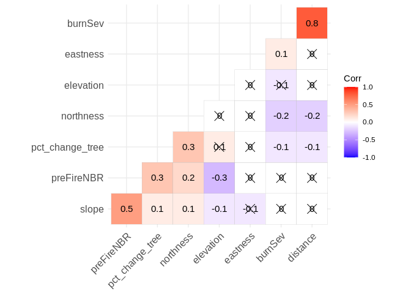

```
patch_data %>%
  ggplot(aes(x = eco_type,y = pct_change_tree)) +
  geom_boxplot() +
  theme(axis.text.x = element_text(angle = 45, hjust = 1))
```

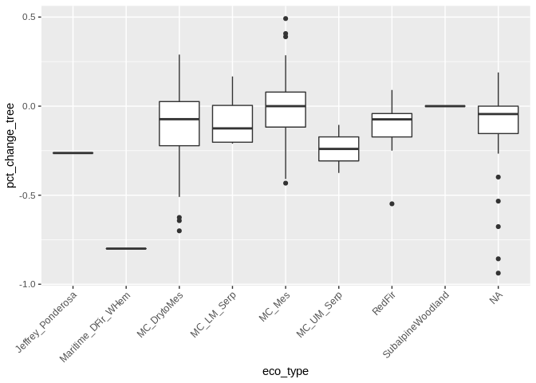

Analyzing the effect of planting trees on the future physiognomic class in fire-affected pixels.

First look at % transitioning in treated and untreated pixels

[output not shown]

[output cut: 312 more lines]

[figure not shown]

Pixel-level data, difference of differences (i.e. t-test)

```
facts_treatment_df <- df %>%
  filter(year > 1986) %>%
  select(clusterID, pixelID, year, landcover_code, factsTreatmentCode) %>%
  mutate(transitioned = pixelID %in% transition2forest) %>%
  mutate(planting = factsTreatmentCode %in% c(4431,4432)) %>%
  #filter(clusterID %in% cluster_with_treatment) %>%
  group_by(pixelID) %>% summarise(clusterID = first(clusterID), tr = first(transitioned), pl = max(planting)) %>%
  group_by(clusterID,pl) %>% summarise(n_tr = sum(tr), n = length(tr)) %>%
  mutate(frac_tr = n_tr / n) %>%
  mutate(lnfrac_tr = log(frac_tr + 0.000001))

#treatGroup <- plantedVSnot %>% filter(pl == 1) %>% pull(frac_tr)

#ControlGroup <- plantedVSnot %>% filter(pl == 0) %>% pull(frac_tr)
```

Visualizing data

```
facts_treatment_df %>%
  ggplot(aes(factor(pl),frac_tr)) +
  geom_boxplot() +
  stat_summary(fun.y = mean, geom="point",colour="darkred", size=3)

## Warning: `fun.y` is deprecated. Use `fun` instead.
```

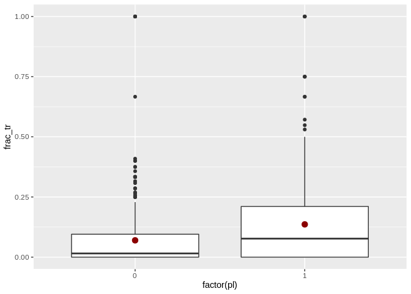

```
facts_treatment_df %>%
ggplot(aes(frac_tr)) +
geom_histogram()
```

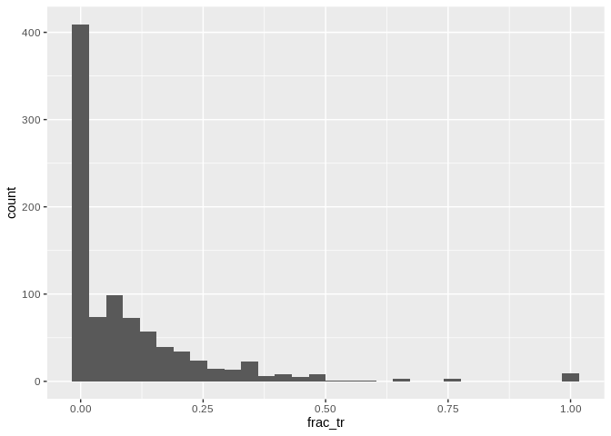

```
facts_treatment_df %>%
ggplot(aes(log(frac_tr))) +
geom_histogram()


## Warning: Removed 395 rows containing non-finite values (stat_bin).
```

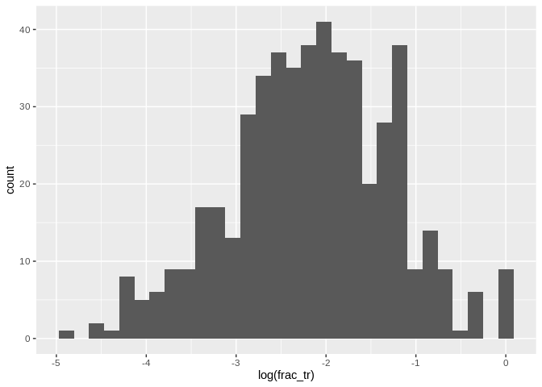

```
clusters_with_treatment <- facts_treatment_df %>%
  drop_na(clusterID) %>%
  group_by(clusterID) %>%
  summarise(nb = length(n)) %>%
  filter(nb > 1) %>% pull(clusterID)

facts_treatment_df %>% filter(clusterID %in% clusters_with_treatment)

## # A tibble: 610 x 6
## # Groups:   clusterID [305]
##    clusterID      pl  n_tr     n frac_tr lnfrac_tr
##    <fct>       <int> <int> <int>   <dbl>     <dbl>
##  1 0               0   128  2004  0.0639     -2.75
##  2 0               1    35   201  0.174      -1.75
##  3 -1121539616     0     0     4  0         -13.8
##  4 -1121539616     1     1     8  0.125      -2.08
##  5 -220987546      0     0     2  0         -13.8
##  6 -220987546      1     0     2  0         -13.8
##  7 -710819746      0     3   166  0.0181     -4.01
##  8 -710819746      1     0     1  0         -13.8
##  9 -1768238605     0     0    84  0         -13.8
## 10 -1768238605     1     0     8  0         -13.8
## # … with 600 more rows

t.test(lnfrac_tr ~ pl,
       data = facts_treatment_df %>% filter(clusterID %in% clusters_with_treatment),
       paired = TRUE)

##
##  Paired t-test
##
## data:  lnfrac_tr by pl
## t = -4.2325, df = 304, p-value = 3.064e-05
## alternative hypothesis: true difference in means is not equal to 0
## 95 percent confidence interval:
##  -2.3944237 -0.8745765
## sample estimates:
## mean of the differences
##                 -1.6345
```